# Week 8 lecture dev

```r
shallow <- read_csv("data/shallow.csv") %>%
  filter(
    Group == "L1",
    Critical_Filler == "Critical",
    RT > 0
  ) %>%
  mutate(
    Accuracy = ifelse(ACC == 1, "correct", "incorrect")
  )
```

The data we’ll use is `shallow` again, and the two predictors we’ll look at are `Relation_type` (same as last week, but we’ll only take two levels of it for today), and `Branching` (two levels).

# 1: Multiple predictors

## Set up data and visualise

Exclude `Relation_type == NonConstituent` and reorder factor levels.

```r
shallow <- shallow %>%
  filter(Relation_type != 'NonConstituent') %>%
  mutate(
    Relation_type = factor(Relation_type, levels = c('Unrelated', 'Constituent')),
    Branching     = factor(Branching, levels = c('Left', 'Right')),
    Accuracy      = factor(Accuracy, levels = c('incorrect', 'correct'))
  )
```

a la sqmf:

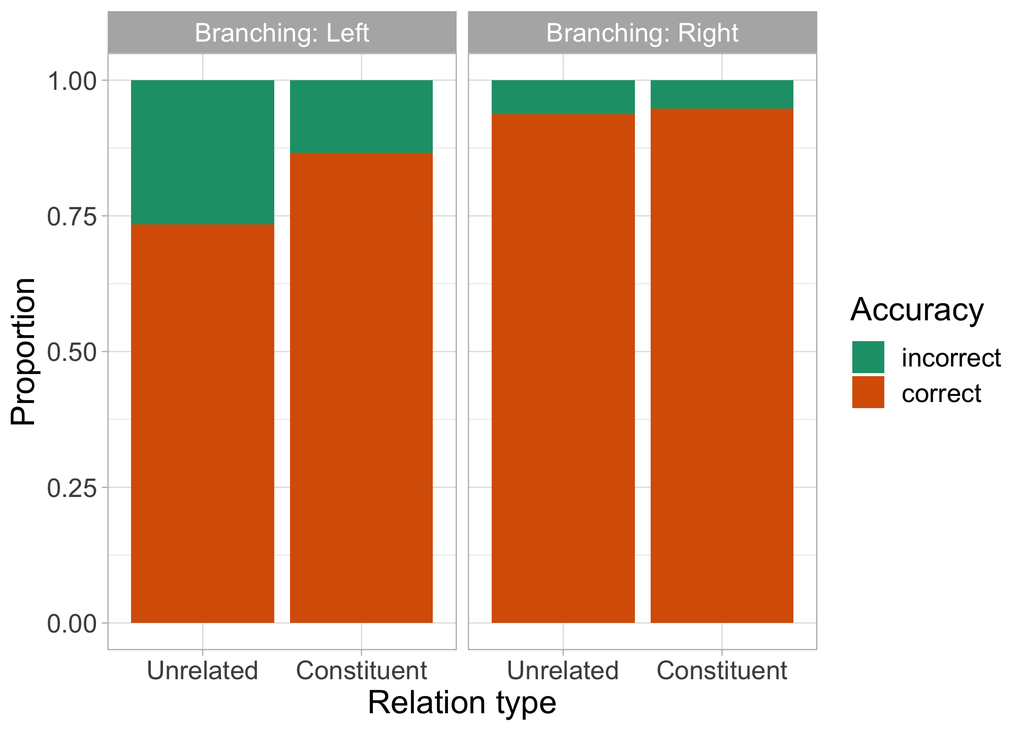

```r
shallow %>%
  ggplot(aes(x = Relation_type, fill = Accuracy)) +
  geom_bar(position = 'fill') +
  facet_wrap(~ Branching, labeller = labeller(Branching = label_both)) +
  labs(y = 'Proportion',
       x = 'Relation type')
```

Reversed grouping (a less obvious difference between differences, bc above ^ there just is none in one condition, so we’ll stick with the above for the lecture):

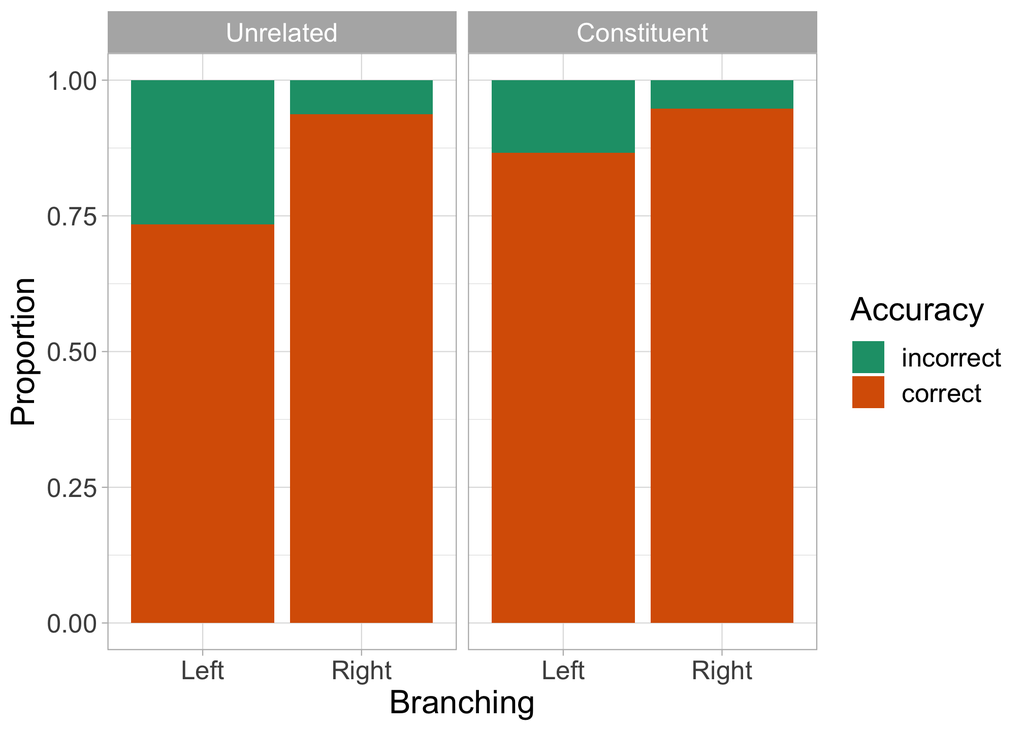

```r
shallow %>%
  ggplot(aes(x = Branching, fill = Accuracy)) +
  geom_bar(position = 'fill') +
  facet_wrap(~ Relation_type) +
  labs(y = 'Proportion')
```

## Check coding

Let’s have a look at the coding that R assigns to each of these variables.

```r
contrasts(shallow$Relation_type)
```

```
            Constituent
Unrelated             0
Constituent           1
```

```r
contrasts(shallow$Branching)
```

```
      Right
Left      0
Right     1
```

The baseline/reference levels are `Relation_type == Unrelated`, and `Branching == Left`.

## Fit the model

```r
acc_mult_bm <- brm(
  Accuracy ~ Relation_type + Branching,
  family = bernoulli(),
  data   = shallow,
  backend = 'cmdstanr',
  file = 'data/cache/acc_mult_bm'
)
```

```r
summary(acc_mult_bm)
```

```
 Family: bernoulli
  Links: mu = logit
Formula: Accuracy ~ Relation_type + Branching
   Data: shallow (Number of observations: 692)
  Draws: 4 chains, each with iter = 2000; warmup = 1000; thin = 1;
         total post-warmup draws = 4000

Population-Level Effects:
                         Estimate Est.Error l-95% CI u-95% CI
Intercept                    1.08      0.17     0.75     1.43
Relation_typeConstituent     0.69      0.25     0.20     1.17
BranchingRight               1.44      0.27     0.91     1.99
                         Rhat Bulk_ESS Tail_ESS
Intercept                1.00     4499     3212
Relation_typeConstituent 1.00     2877     2567
BranchingRight           1.00     2465     2441

Draws were sampled using sample(hmc). For each parameter, Bulk_ESS
and Tail_ESS are effective sample size measures, and Rhat is the potential
scale reduction factor on split chains (at convergence, Rhat = 1).
```

Print only the population-level effects:

```r
cat(capture.output(summary(acc_mult_bm))[8:12], sep = "\n")
```

```
Population-Level Effects:
                         Estimate Est.Error l-95% CI u-95% CI
Intercept                    1.08      0.17     0.75     1.43
Relation_typeConstituent     0.69      0.25     0.20     1.17
BranchingRight               1.44      0.27     0.91     1.99
```

To get the estims as a df:

```r
(mult_coefs <- summary(acc_mult_bm)$fixed)
```

|  | Estimate | Est.Error | l-95% CI | u-95% CI | Rhat | Bulk_ESS | Tail_ESS |
| --- | --- | --- | --- | --- | --- | --- | --- |
| Intercept | 1.0811223 | 0.1686329 | 0.7484602 | 1.430854 | 1.001060 | 4499.389 | 3212.124 |
| Relation_typeConstituent | 0.6911901 | 0.2483435 | 0.2045922 | 1.170172 | 1.002586 | 2876.724 | 2567.440 |
| BranchingRight | 1.4371918 | 0.2736508 | 0.9143428 | 1.985281 | 1.000098 | 2465.100 | 2441.195 |

### Interpreting coefs

Get indiv estims for each coef:

```r
int_estim    <- mult_coefs['Intercept', 'Estimate']
reln_estim   <- mult_coefs['Relation_typeConstituent', 'Estimate']
branch_estim <- mult_coefs['BranchingRight', 'Estimate']
```

```r
int_estim                              # p acc(unrel, left)
```

```
[1] 1.081122
```

```r
int_estim + branch_estim               # p acc(unrel, right)
```

```
[1] 2.518314
```

```r
int_estim + reln_estim                 # p acc(const, left)
```

```
[1] 1.772312
```

```r
int_estim + reln_estim + branch_estim  # p acc(const, right)
```

```
[1] 3.209504
```

```r
round(plogis(int_estim), 2)                              # p acc(unrel, left)
```

```
[1] 0.75
```

```r
round(plogis(int_estim + branch_estim), 2)               # p acc(unrel, right)
```

```
[1] 0.93
```

```r
round(plogis(int_estim + reln_estim), 2)                 # p acc(const, left)
```

```
[1] 0.85
```

```r
round(plogis(int_estim + reln_estim + branch_estim), 2)  # p acc(const, right)
```

```
[1] 0.96
```

### Conditional probabilities

```r
mult_draws <- as_draws_df(acc_mult_bm)

# Compute conditional log-odds
mult_draws_long <- mult_draws %>%
  mutate(
    Unrelated_Left  = b_Intercept,
    Unrelated_Right = b_Intercept + b_BranchingRight,
    Constituent_Left    = b_Intercept + b_Relation_typeConstituent,
    Constituent_Right   = b_Intercept + b_BranchingRight + b_Relation_typeConstituent
  ) %>%
  select(Unrelated_Left:Constituent_Right) %>%
  pivot_longer(everything(), names_to = 'pred_combo', values_to = 'logodds_samples') %>%
  separate(pred_combo, into = c('Relation_type', 'Branching')) %>%
  mutate(
    Relation_type = factor(Relation_type, levels = c('Unrelated', 'Constituent')),
    Branching     = factor(Branching, levels = c('Left', 'Right'))
  )
```

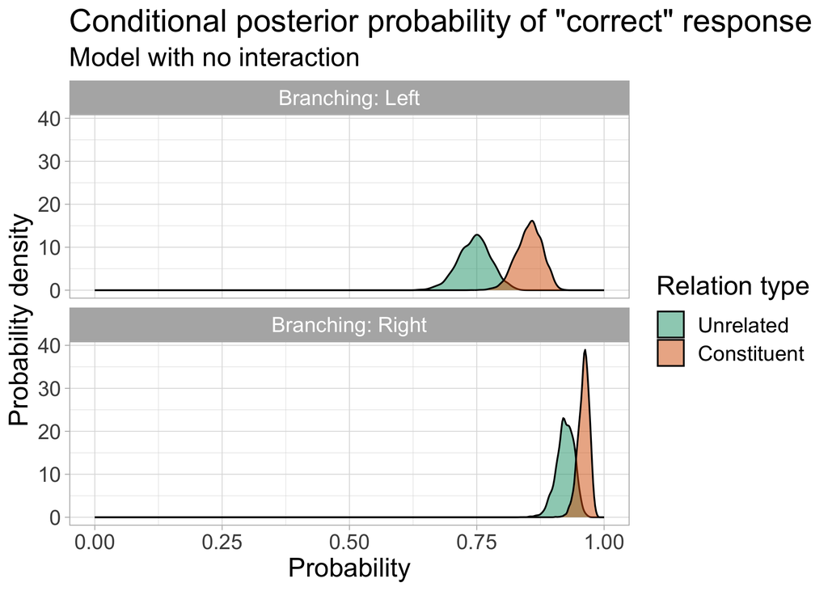

```r
mult_draws_long %>%
  ggplot(aes(x = plogis(logodds_samples), fill = Relation_type)) +
  geom_density(alpha = 0.5) +
  facet_wrap(~ Branching, nrow=2, labeller = labeller(Branching = label_both)) +
  xlim(0, 1) +
  labs(x = 'Probability',
       y = 'Probability density',
       title = 'Conditional posterior probability of "correct" response',
       subtitle = 'Model with no interaction',
       fill = 'Relation type')
```

### 95% CrI in probability space

```r
mult_cri <- mult_draws_long %>%
  group_by(Relation_type, Branching) %>%
  summarise(
    # Calculate the lower and upper bounds of a 95% CrI + mean
    q95_lo = round(quantile2(logodds_samples, probs = 0.025), 2),
    q95_hi = round(quantile2(logodds_samples, probs = 0.975), 2),
    mean_logodds = mean(logodds_samples),
    # Transform into probabilities
    p_q95_lo = round(plogis(q95_lo), 2),
    p_q95_hi = round(plogis(q95_hi), 2),
    p_mean   = round(plogis(mean_logodds), 2)
  )
mult_cri
```

| Relation_type | Branching | q95_lo | q95_hi | mean_logodds | p_q95_lo | p_q95_hi | p_mean |
| --- | --- | --- | --- | --- | --- | --- | --- |
| Unrelated | Left | 0.75 | 1.43 | 1.081122 | 0.68 | 0.81 | 0.75 |
| Unrelated | Right | 2.06 | 3.02 | 2.518314 | 0.89 | 0.95 | 0.93 |
| Constituent | Left | 1.39 | 2.17 | 1.772312 | 0.80 | 0.90 | 0.85 |
| Constituent | Right | 2.67 | 3.80 | 3.209504 | 0.94 | 0.98 | 0.96 |

#### Overlay CrIs on density plot

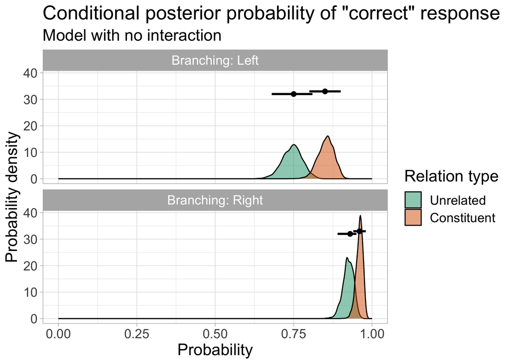

```r
mult_draws_long %>%
  ggplot(aes(x = plogis(logodds_samples))) +
  geom_density(alpha = 0.5, aes(fill = Relation_type)) +
  facet_wrap(~ Branching, nrow=2, labeller = labeller(Branching = label_both)) +
  xlim(0, 1) +
  labs(x = 'Probability',
       y = 'Probability density',
       title = 'Conditional posterior probability of "correct" response',
       subtitle = 'Model with no interaction',
       fill = 'Relation type') +
  # ints + means
  geom_point(data = mult_cri, aes(x = p_mean,
                                  y=c(32, 32, 33, 33),
                                  # colour=Relation_type,
                                  ), size=2) +
  geom_errorbar(data = mult_cri,
                aes(x = p_mean,
                    y=c(32, 32, 33, 33),
                    xmax = p_q95_hi,
                    xmin = p_q95_lo,
                    # colour=Relation_type
                    ),
                width = 0,
                size = 1)
```

### Compare back to data

Overlay these estimates on the actual data. Does this feel right?

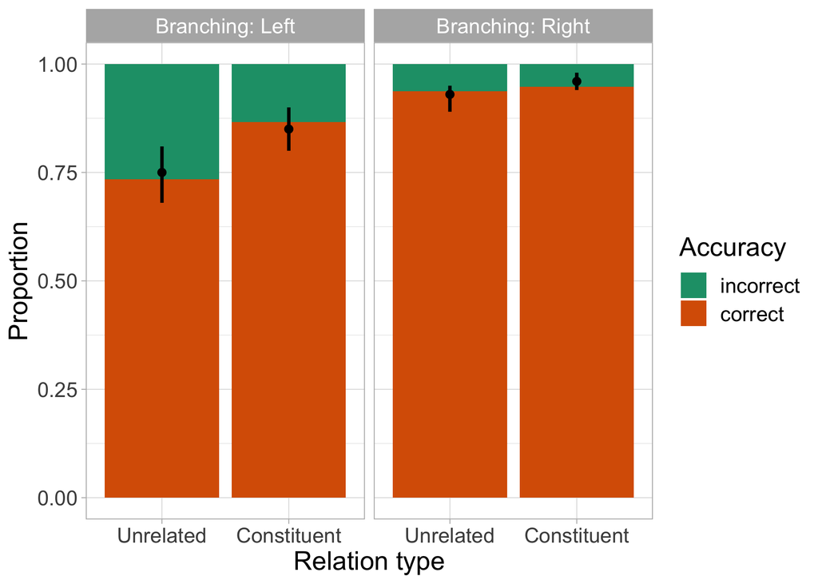

```r
# Manual recreation
barplot_shallow <- shallow %>%
  group_by(Relation_type, Branching) %>%
  summarise(correct = mean(ACC)) %>%
  mutate(incorrect = 1 - correct) %>%
  pivot_longer(correct:incorrect, names_to = 'Accuracy', values_to = 'propn') %>%
  mutate(Accuracy = factor(Accuracy, levels = c('incorrect', 'correct'))) %>%
  # gg the plot
  ggplot(aes(x = Relation_type, y = propn)) +
  geom_bar(stat = 'identity', aes(fill = Accuracy)) +
  facet_wrap(~ Branching, labeller = labeller(Branching = label_both)) +
  labs(y = 'Proportion',
       x = 'Relation type')

# Add in the model's estimates as points + error bars
(barplot_shallow_mult <- barplot_shallow +
  geom_point(data = mult_cri, aes(y = p_mean), size=2) +
  geom_errorbar(data = mult_cri,
                aes(y = p_mean, ymax = p_q95_hi, ymin = p_q95_lo),
                width = 0,
                size = 1) +
  NULL)
```

The model assumes there’s a difference in Branching = Right where there doesn’t seem to be one. And because that difference is small, it’s also underestimating the larger difference in Branching = Left.

If only there were some way to tell the model that the effect of relation type can be different between the two levels of branching.

Oh wait…

# 2: Interactions

## Shallow barplot with diff of diffs

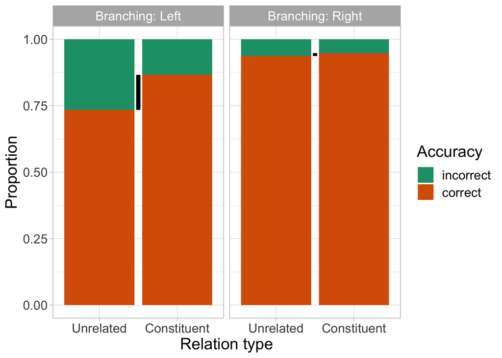

```r
shallow_endpts <- shallow %>%
  group_by(Relation_type, Branching) %>%
  summarise(correct = mean(ACC)) %>%
  pivot_wider(names_from = Relation_type, values_from = correct)

barplot_shallow +
  geom_segment(data = shallow_endpts,
               size = 2,
               aes(y = Unrelated, yend = Constituent, x = 1.5, xend = 1.5))
```

## Fit the model

You’ll also see this syntax for interactions: `Relation_type * Branching`, which secretly fits all three things we fit individually below. But I don’t like secrets.

```r
acc_inter_bm <- brm(
  Accuracy ~ Relation_type + Branching + Relation_type:Branching,
  family = bernoulli(),
  data   = shallow,
  backend = 'cmdstanr',
  file = 'data/cache/acc_inter_bm'
)
```

```r
summary(acc_inter_bm)
```

```
 Family: bernoulli
  Links: mu = logit
Formula: Accuracy ~ Relation_type + Branching + Relation_type:Branching
   Data: shallow (Number of observations: 692)
  Draws: 4 chains, each with iter = 2000; warmup = 1000; thin = 1;
         total post-warmup draws = 4000

Population-Level Effects:
                                        Estimate Est.Error
Intercept                                   1.02      0.17
Relation_typeConstituent                    0.85      0.29
BranchingRight                              1.69      0.36
Relation_typeConstituent:BranchingRight    -0.63      0.55
                                        l-95% CI u-95% CI Rhat
Intercept                                   0.69     1.38 1.00
Relation_typeConstituent                    0.28     1.43 1.00
BranchingRight                              1.04     2.42 1.00
Relation_typeConstituent:BranchingRight    -1.72     0.42 1.00
                                        Bulk_ESS Tail_ESS
Intercept                                   3445     3109
Relation_typeConstituent                    2527     2141
BranchingRight                              2131     2325
Relation_typeConstituent:BranchingRight     1860     2203

Draws were sampled using sample(hmc). For each parameter, Bulk_ESS
and Tail_ESS are effective sample size measures, and Rhat is the potential
scale reduction factor on split chains (at convergence, Rhat = 1).
```

Print only the population-level effects:

```r
cat(capture.output(summary(acc_inter_bm))[8:13], sep = "\n")
```

```
Population-Level Effects:
                                        Estimate Est.Error
Intercept                                   1.02      0.17
Relation_typeConstituent                    0.85      0.29
BranchingRight                              1.69      0.36
Relation_typeConstituent:BranchingRight    -0.63      0.55
```

To get the estims as a df:

```r
(inter_coefs <- summary(acc_inter_bm)$fixed)
```

|  | Estimate | Est.Error | l-95% CI | u-95% CI | Rhat | Bulk_ESS | Tail_ESS |
| --- | --- | --- | --- | --- | --- | --- | --- |
| Intercept | 1.0233481 | 0.1747096 | 0.6865851 | 1.3764772 | 1.002133 | 3445.462 | 3109.260 |
| Relation_typeConstituent | 0.8533669 | 0.2887819 | 0.2846567 | 1.4257775 | 1.000790 | 2526.684 | 2140.952 |
| BranchingRight | 1.6934382 | 0.3571853 | 1.0369578 | 2.4241485 | 1.000221 | 2131.445 | 2325.485 |
| Relation_typeConstituent:BranchingRight | -0.6348752 | 0.5511829 | -1.7178148 | 0.4183512 | 1.001000 | 1859.650 | 2202.805 |

### Interpreting coefs

Get indiv estims for each coef:

```r
int_estim2    <- inter_coefs['Intercept', 'Estimate']
reln_estim2   <- inter_coefs['Relation_typeConstituent', 'Estimate']
branch_estim2 <- inter_coefs['BranchingRight', 'Estimate']
inter_estim   <- inter_coefs['Relation_typeConstituent:BranchingRight', 'Estimate']
```

GelmanHill2007 p. 93 interpretation (with both possible mappings of interacting vars to VAR1 and VAR2):

> Moving from VAR1_BASELINE to VAR1_NON-BASELINE of VAR1, the value INTERACTION_COEF is added to the coefficient for VAR2. We have already seen that the coefficient for VAR2 is VAR2_COEF at the baseline level of VAR1, and so we can understand the interaction as saying that the importance of VAR2 as a predictor [*increases* if signs of VAR2_COEF and INTERACTION_COEF are the same/*decreases* if signs of VAR2_COEF and INTERACTION_COEF are different(?)] when we move from VAR1_BASELINE to VAR1_NON-BASELINE.
1. Moving from `Unrelated` to `Constituent`, the value -0.63 is added to the coefficient for `Branching`. We have already seen that the coefficient for `Branching` is 1.69 at the baseline level of `Relation_type`, and so we can understand the interaction as saying that the effect of `Branching` gets smaller when we move from `Unrelated` relation types to `Constituent` relation types.
2. Moving from `Left` to `Right`, the value -0.63 is added to the coefficient for `Relation_type`. We have already seen that the coefficient for `Relation_type` is 0.85 at the baseline level of `Branching`, and so we can understand the interaction as saying that the effect of `Relation_type` gets smaller when we move from `Left` branching to `Right` branching structures.

Interpretation (2) is the one that goes with the data that we’ll see in the lecture (and it makes sense when looking at the plot, we can see it!). So that’s the interpretation that we’ll focus on for ease of storytelling for the lec.

### Cond probs

Put ’em together to get new conditional probability means:

```r
round(plogis(int_estim2), 2)                               # p acc(unrel, left)
```

```
[1] 0.74
```

```r
round(plogis(int_estim2 + branch_estim2), 2)               # p acc(unrel, right)
```

```
[1] 0.94
```

```r
round(plogis(int_estim2 + reln_estim2), 2)                 # p acc(const, left)
```

```
[1] 0.87
```

```r
round(plogis(int_estim2 + reln_estim2 + branch_estim2 + inter_estim), 2)  # p acc(const, right)
```

```
[1] 0.95
```

```r
inter_draws <- as_draws_df(acc_inter_bm)

# Compute conditional log-odds
inter_draws_long <- inter_draws %>%
  mutate(
    Unrelated_Left  = b_Intercept,
    Unrelated_Right = b_Intercept + b_BranchingRight,
    Constituent_Left    = b_Intercept + b_Relation_typeConstituent,
    Constituent_Right   = b_Intercept + b_BranchingRight + b_Relation_typeConstituent + `b_Relation_typeConstituent:BranchingRight`
  ) %>%
  select(Unrelated_Left:Constituent_Right) %>%
  pivot_longer(everything(), names_to = 'pred_combo', values_to = 'logodds_samples') %>%
  separate(pred_combo, into = c('Relation_type', 'Branching')) %>%
  mutate(
    Relation_type = factor(Relation_type, levels = c('Unrelated', 'Constituent')),
    Branching     = factor(Branching, levels = c('Left', 'Right'))
  )
```

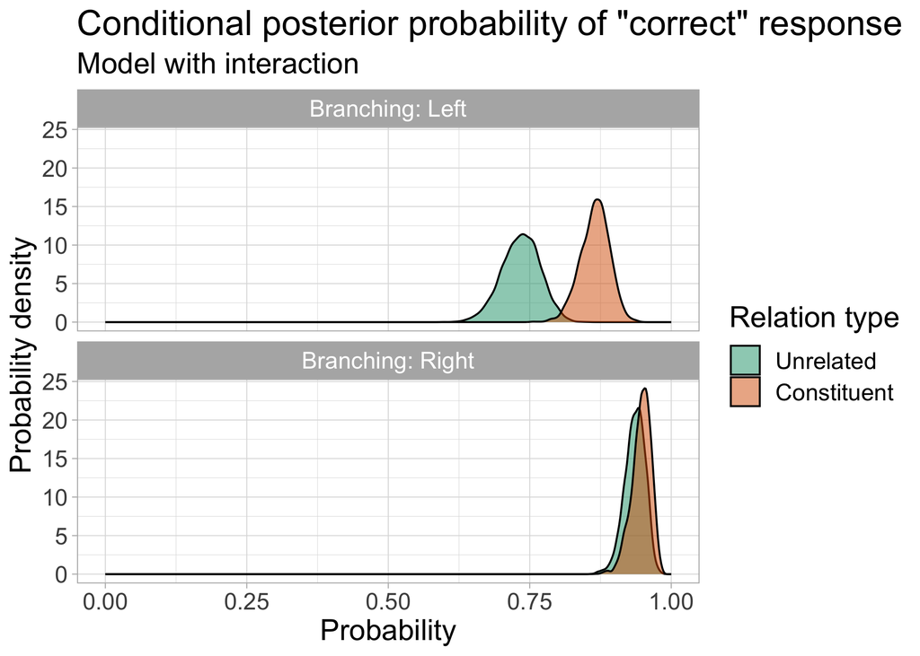

```r
inter_draws_long %>%
  ggplot(aes(x = plogis(logodds_samples), fill = Relation_type)) +
  geom_density(alpha = 0.5) +
  facet_wrap(~ Branching, nrow=2, labeller = labeller(Branching = label_both)) +
  xlim(0, 1) +
  labs(x = 'Probability',
       y = 'Probability density',
       title = 'Conditional posterior probability of "correct" response',
       subtitle = 'Model with interaction',
       fill = 'Relation type')
```

### 95% CrI in probability space

```r
inter_cri <- inter_draws_long %>%
  group_by(Relation_type, Branching) %>%
  summarise(
    # Calculate the lower and upper bounds of a 95% CrI + mean
    q95_lo = round(quantile2(logodds_samples, probs = 0.025), 2),
    q95_hi = round(quantile2(logodds_samples, probs = 0.975), 2),
    mean_logodds = mean(logodds_samples),
    # Transform into probabilities
    p_q95_lo = round(plogis(q95_lo), 2),
    p_q95_hi = round(plogis(q95_hi), 2),
    p_mean   = round(plogis(mean_logodds), 2)
  )
inter_cri
```

| Relation_type | Branching | q95_lo | q95_hi | mean_logodds | p_q95_lo | p_q95_hi | p_mean |
| --- | --- | --- | --- | --- | --- | --- | --- |
| Unrelated | Left | 0.69 | 1.38 | 1.023348 | 0.67 | 0.80 | 0.74 |
| Unrelated | Right | 2.16 | 3.35 | 2.716786 | 0.90 | 0.97 | 0.94 |
| Constituent | Left | 1.46 | 2.34 | 1.876715 | 0.81 | 0.91 | 0.87 |
| Constituent | Right | 2.30 | 3.64 | 2.935278 | 0.91 | 0.97 | 0.95 |

### Compare back to data

Overlay these estimates on the actual data. Does this feel right?

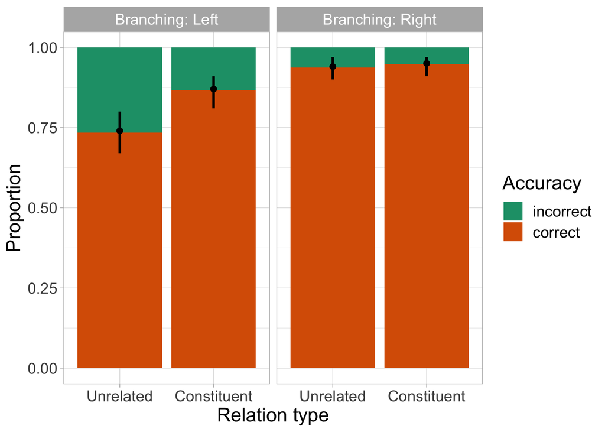

```r
# Add in the model's estimates as points + error bars
(barplot_shallow_inter <- barplot_shallow +
  geom_point(data = inter_cri, aes(y = p_mean), size=2) +
  geom_errorbar(data = inter_cri,
                aes(y = p_mean, ymax = p_q95_hi, ymin = p_q95_lo),
                width = 0,
                size = 1) +
  NULL)
```